# INN Hotels Project

## Context

A significant number of hotel bookings are called-off due to cancellations or no-shows. The typical reasons for cancellations include change of plans, scheduling conflicts, etc. This is often made easier by the option to do so free of charge or preferably at a low cost which is beneficial to hotel guests but it is a less desirable and possibly revenue-diminishing factor for hotels to deal with. Such losses are particularly high on last-minute cancellations.

The new technologies involving online booking channels have dramatically changed customers’ booking possibilities and behavior. This adds a further dimension to the challenge of how hotels handle cancellations, which are no longer limited to traditional booking and guest characteristics.

The cancellation of bookings impact a hotel on various fronts:

- Loss of resources (revenue) when the hotel cannot resell the room.
- Additional costs of distribution channels by increasing commissions or paying for publicity to help sell these rooms.
- Lowering prices last minute, so the hotel can resell a room, resulting in reducing the profit margin.
- Human resources to make arrangements for the guests.

## Objective

The increasing number of cancellations calls for a Machine Learning based solution that can help in predicting which booking is likely to be canceled. INN Hotels Group has a chain of hotels in Portugal, they are facing problems with the high number of booking cancellations and have reached out to your firm for data-driven solutions. You as a data scientist have to analyze the data provided to find which factors have a high influence on booking cancellations, build a predictive model that can predict which booking is going to be canceled in advance, and help in formulating profitable policies for cancellations and refunds.

## Data Description

The data contains the different attributes of customers' booking details. The detailed data dictionary is given below.

**Data Dictionary**

- Booking_ID: unique identifier of each booking
- no_of_adults: Number of adults
- no_of_children: Number of Children
- no_of_weekend_nights: Number of weekend nights (Saturday or Sunday) the guest stayed or booked to stay at the hotel
- no_of_week_nights: Number of week nights (Monday to Friday) the guest stayed or booked to stay at the hotel
- type_of_meal_plan: Type of meal plan booked by the customer:
  - Not Selected – No meal plan selected
  - Meal Plan 1 – Breakfast
  - Meal Plan 2 – Half board (breakfast and one other meal)
  - Meal Plan 3 – Full board (breakfast, lunch, and dinner)
- required_car_parking_space: Does the customer require a car parking space? (0 - No, 1- Yes)
- room_type_reserved: Type of room reserved by the customer. The values are ciphered (encoded) by INN Hotels.
- lead_time: Number of days between the date of booking and the arrival date
- arrival_year: Year of arrival date
- arrival_month: Month of arrival date
- arrival_date: Date of the month
- market_segment_type: Market segment designation.
- repeated_guest: Is the customer a repeated guest? (0 - No, 1- Yes)
- no_of_previous_cancellations: Number of previous bookings that were canceled by the customer prior to the current booking
- no_of_previous_bookings_not_canceled: Number of previous bookings not canceled by the customer prior to the current booking
- avg_price_per_room: Average price per day of the reservation; prices of the rooms are dynamic. (in euros)
- no_of_special_requests: Total number of special requests made by the customer (e.g. high floor, view from the room, etc)
- booking_status: Flag indicating if the booking was canceled or not.

## Importing necessary libraries and data

```python
# this will help in making the Python code more structured automatically (good coding practice)
#%load_ext nb_black

import warnings

warnings.filterwarnings("ignore")
from statsmodels.tools.sm_exceptions import ConvergenceWarning

warnings.simplefilter("ignore", ConvergenceWarning)

# Libraries to help with reading and manipulating data

import pandas as pd
import numpy as np

# Library to split data
from sklearn.model_selection import train_test_split

# libaries to help with data visualization
import matplotlib.pyplot as plt
import seaborn as sns

# Removes the limit for the number of displayed columns
pd.set_option("display.max_columns", None)
# Sets the limit for the number of displayed rows
pd.set_option("display.max_rows", 200)


# To build model for prediction
import statsmodels.stats.api as sms
from statsmodels.stats.outliers_influence import variance_inflation_factor
import statsmodels.api as sm
from statsmodels.tools.tools import add_constant
from sklearn.linear_model import LogisticRegression


# To get diferent metric scores
from sklearn.metrics import (
    f1_score,
    accuracy_score,
    recall_score,
    precision_score,
    confusion_matrix,
    roc_auc_score,
    plot_confusion_matrix,
    precision_recall_curve,
    roc_curve,
)

booking = pd.read_csv("INNHotelsGroup.csv")
#copy data changes for sanity checks later down the line
data = booking.copy()
```

## Data Overview

- Observations
- Sanity checks

```python
# check the first 5 rows of the dataset
data.head()
```

|  | Booking_ID | no_of_adults | no_of_children | no_of_weekend_nights | no_of_week_nights | type_of_meal_plan | required_car_parking_space | room_type_reserved | lead_time | arrival_year | arrival_month | arrival_date | market_segment_type | repeated_guest | no_of_previous_cancellations | no_of_previous_bookings_not_canceled | avg_price_per_room | no_of_special_requests | booking_status |
| --- | --- | --- | --- | --- | --- | --- | --- | --- | --- | --- | --- | --- | --- | --- | --- | --- | --- | --- | --- |
| 0 | INN00001 | 2 | 0 | 1 | 2 | Meal Plan 1 | 0 | Room_Type 1 | 224 | 2017 | 10 | 2 | Offline | 0 | 0 | 0 | 65.00 | 0 | Not_Canceled |
| 1 | INN00002 | 2 | 0 | 2 | 3 | Not Selected | 0 | Room_Type 1 | 5 | 2018 | 11 | 6 | Online | 0 | 0 | 0 | 106.68 | 1 | Not_Canceled |
| 2 | INN00003 | 1 | 0 | 2 | 1 | Meal Plan 1 | 0 | Room_Type 1 | 1 | 2018 | 2 | 28 | Online | 0 | 0 | 0 | 60.00 | 0 | Canceled |
| 3 | INN00004 | 2 | 0 | 0 | 2 | Meal Plan 1 | 0 | Room_Type 1 | 211 | 2018 | 5 | 20 | Online | 0 | 0 | 0 | 100.00 | 0 | Canceled |
| 4 | INN00005 | 2 | 0 | 1 | 1 | Not Selected | 0 | Room_Type 1 | 48 | 2018 | 4 | 11 | Online | 0 | 0 | 0 | 94.50 | 0 | Canceled |

```python
# checking the last 5 rows of the dataset
data.tail()
```

|  | Booking_ID | no_of_adults | no_of_children | no_of_weekend_nights | no_of_week_nights | type_of_meal_plan | required_car_parking_space | room_type_reserved | lead_time | arrival_year | arrival_month | arrival_date | market_segment_type | repeated_guest | no_of_previous_cancellations | no_of_previous_bookings_not_canceled | avg_price_per_room | no_of_special_requests | booking_status |
| --- | --- | --- | --- | --- | --- | --- | --- | --- | --- | --- | --- | --- | --- | --- | --- | --- | --- | --- | --- |
| 36270 | INN36271 | 3 | 0 | 2 | 6 | Meal Plan 1 | 0 | Room_Type 4 | 85 | 2018 | 8 | 3 | Online | 0 | 0 | 0 | 167.80 | 1 | Not_Canceled |
| 36271 | INN36272 | 2 | 0 | 1 | 3 | Meal Plan 1 | 0 | Room_Type 1 | 228 | 2018 | 10 | 17 | Online | 0 | 0 | 0 | 90.95 | 2 | Canceled |
| 36272 | INN36273 | 2 | 0 | 2 | 6 | Meal Plan 1 | 0 | Room_Type 1 | 148 | 2018 | 7 | 1 | Online | 0 | 0 | 0 | 98.39 | 2 | Not_Canceled |
| 36273 | INN36274 | 2 | 0 | 0 | 3 | Not Selected | 0 | Room_Type 1 | 63 | 2018 | 4 | 21 | Online | 0 | 0 | 0 | 94.50 | 0 | Canceled |
| 36274 | INN36275 | 2 | 0 | 1 | 2 | Meal Plan 1 | 0 | Room_Type 1 | 207 | 2018 | 12 | 30 | Offline | 0 | 0 | 0 | 161.67 | 0 | Not_Canceled |

- At first glance, it appears that bringing children is uncommon.
- Meal Plan 1 appears to be the most common.

```python
# understand the shape of the dataset
data.shape
```

```
(36275, 19)
```

- The dataset has 36275 rows and 19 columns.

```python
# check the data types of the columns for the dataset
data.info()
```

```
<class 'pandas.core.frame.DataFrame'>
RangeIndex: 36275 entries, 0 to 36274
Data columns (total 19 columns):
 #   Column                                Non-Null Count  Dtype
---  ------                                --------------  -----
 0   Booking_ID                            36275 non-null  object
 1   no_of_adults                          36275 non-null  int64
 2   no_of_children                        36275 non-null  int64
 3   no_of_weekend_nights                  36275 non-null  int64
 4   no_of_week_nights                     36275 non-null  int64
 5   type_of_meal_plan                     36275 non-null  object
 6   required_car_parking_space            36275 non-null  int64
 7   room_type_reserved                    36275 non-null  object
 8   lead_time                             36275 non-null  int64
 9   arrival_year                          36275 non-null  int64
 10  arrival_month                         36275 non-null  int64
 11  arrival_date                          36275 non-null  int64
 12  market_segment_type                   36275 non-null  object
 13  repeated_guest                        36275 non-null  int64
 14  no_of_previous_cancellations          36275 non-null  int64
 15  no_of_previous_bookings_not_canceled  36275 non-null  int64
 16  avg_price_per_room                    36275 non-null  float64
 17  no_of_special_requests                36275 non-null  int64
 18  booking_status                        36275 non-null  object
dtypes: float64(1), int64(13), object(5)
memory usage: 5.3+ MB
```

- It appears there are no missing values in the dataset.
- All columns but booking_id, type_of_meal_plan, room_type_reserved, market_segment_type, and booking_status are continuous variables.
- The dependent variable is booking_status, which is a categorical variable. This means logistic regression can be used to model the data.

```python
# check for duplicate values:
data.duplicated().sum()
```

```
0
```

- There are no duplicate values in the dataset.

```python
# check for missing values:
data.isnull().sum()
```

```
Booking_ID                              0
no_of_adults                            0
no_of_children                          0
no_of_weekend_nights                    0
no_of_week_nights                       0
type_of_meal_plan                       0
required_car_parking_space              0
room_type_reserved                      0
lead_time                               0
arrival_year                            0
arrival_month                           0
arrival_date                            0
market_segment_type                     0
repeated_guest                          0
no_of_previous_cancellations            0
no_of_previous_bookings_not_canceled    0
avg_price_per_room                      0
no_of_special_requests                  0
booking_status                          0
dtype: int64
```

- There are no missing values in the dataset.

**Statistical Summary**

```python
data.describe().T
```

|  | count | mean | std | min | 25% | 50% | 75% | max |
| --- | --- | --- | --- | --- | --- | --- | --- | --- |
| no_of_adults | 36275.0 | 1.844962 | 0.518715 | 0.0 | 2.0 | 2.00 | 2.0 | 4.0 |
| no_of_children | 36275.0 | 0.105279 | 0.402648 | 0.0 | 0.0 | 0.00 | 0.0 | 10.0 |
| no_of_weekend_nights | 36275.0 | 0.810724 | 0.870644 | 0.0 | 0.0 | 1.00 | 2.0 | 7.0 |
| no_of_week_nights | 36275.0 | 2.204300 | 1.410905 | 0.0 | 1.0 | 2.00 | 3.0 | 17.0 |
| required_car_parking_space | 36275.0 | 0.030986 | 0.173281 | 0.0 | 0.0 | 0.00 | 0.0 | 1.0 |
| lead_time | 36275.0 | 85.232557 | 85.930817 | 0.0 | 17.0 | 57.00 | 126.0 | 443.0 |
| arrival_year | 36275.0 | 2017.820427 | 0.383836 | 2017.0 | 2018.0 | 2018.00 | 2018.0 | 2018.0 |
| arrival_month | 36275.0 | 7.423653 | 3.069894 | 1.0 | 5.0 | 8.00 | 10.0 | 12.0 |
| arrival_date | 36275.0 | 15.596995 | 8.740447 | 1.0 | 8.0 | 16.00 | 23.0 | 31.0 |
| repeated_guest | 36275.0 | 0.025637 | 0.158053 | 0.0 | 0.0 | 0.00 | 0.0 | 1.0 |
| no_of_previous_cancellations | 36275.0 | 0.023349 | 0.368331 | 0.0 | 0.0 | 0.00 | 0.0 | 13.0 |
| no_of_previous_bookings_not_canceled | 36275.0 | 0.153411 | 1.754171 | 0.0 | 0.0 | 0.00 | 0.0 | 58.0 |
| avg_price_per_room | 36275.0 | 103.423539 | 35.089424 | 0.0 | 80.3 | 99.45 | 120.0 | 540.0 |
| no_of_special_requests | 36275.0 | 0.619655 | 0.786236 | 0.0 | 0.0 | 0.00 | 1.0 | 5.0 |

## Exploratory Data Analysis (EDA)

- EDA is an important part of any project involving data.
- It is important to investigate and understand the data better before building a model with it.
- A few questions have been mentioned below which will help you approach the analysis in the right manner and generate insights from the data.
- A thorough analysis of the data, in addition to the questions mentioned below, should be done.

**Helper functions created for EDA:**

```python
def histogram_boxplot(data, feature, figsize=(15, 10), kde=False, bins=None):
    """
    Boxplot and histogram combined

    data: dataframe
    feature: dataframe column
    figsize: size of figure (default (15,10))
    kde: whether to show the density curve (default False)
    bins: number of bins for histogram (default None)
    """
    f2, (ax_box2, ax_hist2) = plt.subplots(
        nrows=2,  # Number of rows of the subplot grid= 2
        sharex=True,  # x-axis will be shared among all subplots
        gridspec_kw={"height_ratios": (0.25, 0.75)},
        figsize=figsize,
    )  # creating the 2 subplots
    sns.boxplot(
        data=data, x=feature, ax=ax_box2, showmeans=True, color="violet"
    )  # boxplot will be created and a triangle will indicate the mean value of the column
    sns.histplot(
        data=data, x=feature, kde=kde, ax=ax_hist2, bins=bins
    ) if bins else sns.histplot(
        data=data, x=feature, kde=kde, ax=ax_hist2
    )  # For histogram
    ax_hist2.axvline(
        data[feature].mean(), color="green", linestyle="--"
    )  # Add mean to the histogram
    ax_hist2.axvline(
        data[feature].median(), color="black", linestyle="-"
    )  # Add median to the histogram
```

```python
# function to create labeled barplots


def labeled_barplot(data, feature, perc=False, n=None):
    """
    Barplot with percentage at the top

    data: dataframe
    feature: dataframe column
    perc: whether to display percentages instead of count (default is False)
    n: displays the top n category levels (default is None, i.e., display all levels)
    """

    total = len(data[feature])  # length of the column
    count = data[feature].nunique()
    if n is None:
        plt.figure(figsize=(count + 2, 6))
    else:
        plt.figure(figsize=(n + 2, 6))

    plt.xticks(rotation=90, fontsize=15)
    ax = sns.countplot(
        data=data,
        x=feature,
        palette="Paired",
        order=data[feature].value_counts().index[:n],
    )

    for p in ax.patches:
        if perc == True:
            label = "{:.1f}%".format(
                100 * p.get_height() / total
            )  # percentage of each class of the category
        else:
            label = p.get_height()  # count of each level of the category

        x = p.get_x() + p.get_width() / 2  # width of the plot
        y = p.get_height()  # height of the plot

        ax.annotate(
            label,
            (x, y),
            ha="center",
            va="center",
            size=12,
            xytext=(0, 5),
            textcoords="offset points",
        )  # annotate the percentage
```

```python
def stacked_barplot(data, predictor, target):
    """
    Print the category counts and plot a stacked bar chart

    data: dataframe
    predictor: independent variable
    target: target variable
    """
    count = data[predictor].nunique()
    sorter = data[target].value_counts().index[-1]
    tab1 = pd.crosstab(data[predictor], data[target], margins=True).sort_values(
        by=sorter, ascending=False
    )
    print(tab1)
    print("-" * 120)
    tab = pd.crosstab(data[predictor], data[target], normalize="index").sort_values(
        by=sorter, ascending=False
    )
    tab.plot(kind="bar", stacked=True, figsize=(count + 5, 5))
    plt.legend(
        loc="lower left", frameon=False,
    )
    plt.legend(loc="upper left", bbox_to_anchor=(1, 1))
    plt.show()
```

```python
### function to plot distributions wrt target


def distribution_plot_wrt_target(data, predictor, target):

    fig, axs = plt.subplots(2, 2, figsize=(12, 10))

    target_uniq = data[target].unique()

    axs[0, 0].set_title("Distribution of target for target=" + str(target_uniq[0]))
    sns.histplot(
        data=data[data[target] == target_uniq[0]],
        x=predictor,
        kde=True,
        ax=axs[0, 0],
        color="teal",
        stat="density",
    )

    axs[0, 1].set_title("Distribution of target for target=" + str(target_uniq[1]))
    sns.histplot(
        data=data[data[target] == target_uniq[1]],
        x=predictor,
        kde=True,
        ax=axs[0, 1],
        color="orange",
        stat="density",
    )

    axs[1, 0].set_title("Boxplot w.r.t target")
    sns.boxplot(data=data, x=target, y=predictor, ax=axs[1, 0], palette="gist_rainbow")

    axs[1, 1].set_title("Boxplot (without outliers) w.r.t target")
    sns.boxplot(
        data=data,
        x=target,
        y=predictor,
        ax=axs[1, 1],
        showfliers=False,
        palette="gist_rainbow",
    )

    plt.tight_layout()
    plt.show()
```

```python
df = data.copy()
```

**Univariate Analysis:**

**Booking_ID:**

```python
df["Booking_ID"].unique().size
```

```
36275
```

There are as many book ID's as there are rows so each Booking ID is unique.

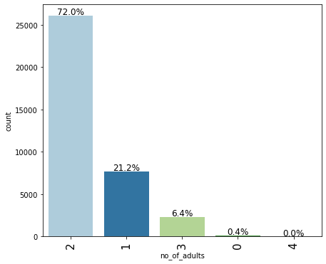

```python
labeled_barplot(df, "no_of_adults", perc=True)
```

- 72% of the bookings are made up of couples.
- .4% of the bookings are comprised of 0 adults. We should treat that as an outlier since a booking requires at least one adult.

**No_of_children:**

- Over 90 percent of bookings do not have any children. That could be because few people take their children on international trips.

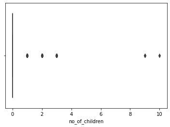

```python
# Let's check for outliers:
sns.boxplot(data=df,x="no_of_children")
plt.show()
```

According to the boxplot below, having *any* amount of children is considered an outlier in the data.

**No_of_weekend_nights:**

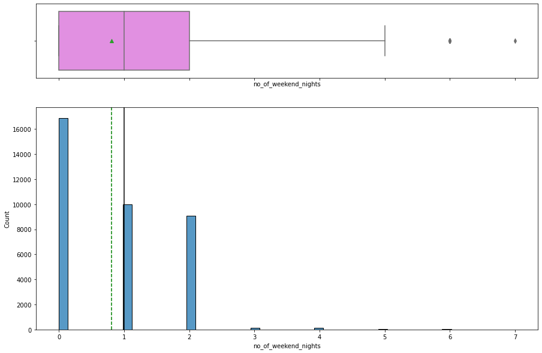

```python
histogram_boxplot(df, "no_of_weekend_nights", bins=50)
```

**No_of_week_nights:**

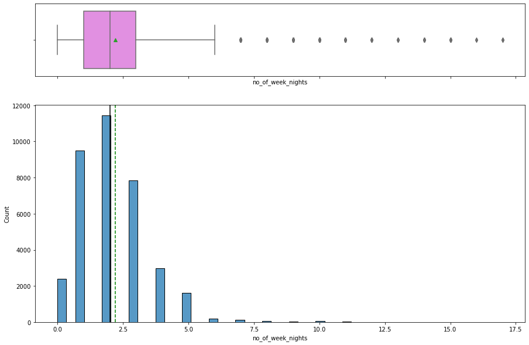

```python
histogram_boxplot(df, "no_of_week_nights", bins=50)
```

- Week nights are more prevalent that weekend_nights.
- A large number of outliers are present.

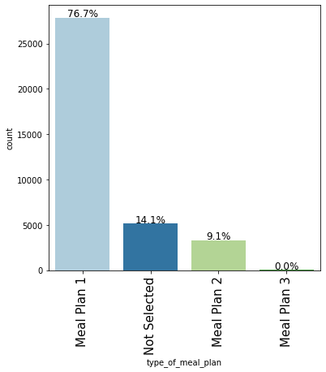

```python
labeled_barplot(df, "type_of_meal_plan", perc=True)
```

- Meal plan 3 will have to be removed once meal plan is converted into dummy variables because there will not be enough data in that column.

**Required_car_parking_space:**

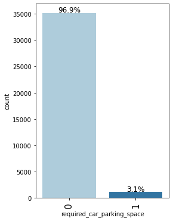

```python
labeled_barplot(df, "required_car_parking_space", perc=True)
```

- The vast majority of people do not require a parking space (96.9%). It is likely most people get around by public transit.
- 3.1% of people require 1 parking space.

**Lead_Time**:

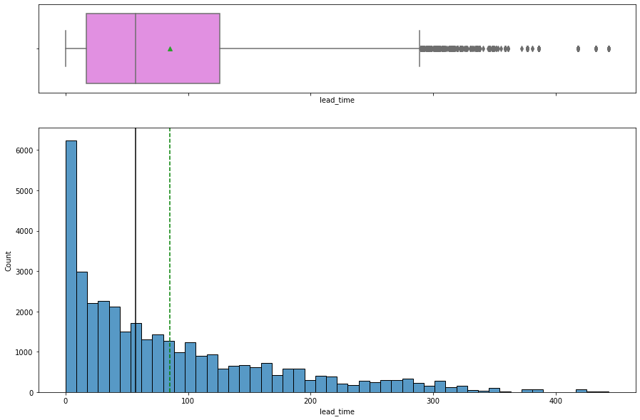

```python
histogram_boxplot(df, "lead_time", bins=50)
```

- The mode of the data is 0 days, while the mean is ~85 days.
- Data is right skewed and contains several outliers.

**Arrival_year:**

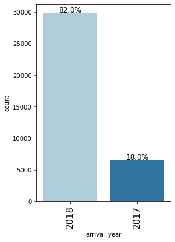

```python
labeled_barplot(df, "arrival_year", perc=True)
```

- 82% of the bookings were from the year 2018 and 18 percent came from 2017.

**Arrival_month**:

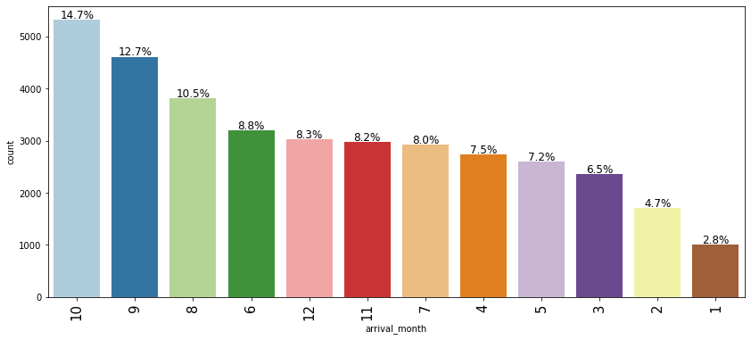

```python
labeled_barplot(df, "arrival_month", perc=True)
```

- October is the month with the highest number of bookings, followed by September and August.
- January is the least popular month.

**Arrival_date:**

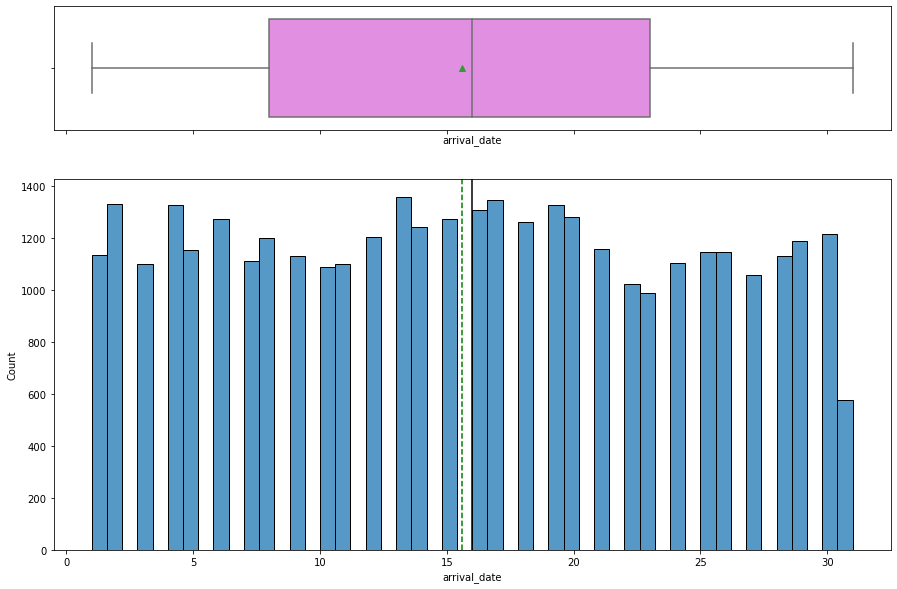

```python
histogram_boxplot(df, "arrival_date", bins=50)
```

- The arrival date data appears close to being uniformly distributed.
- The range is 1-31, as expected.

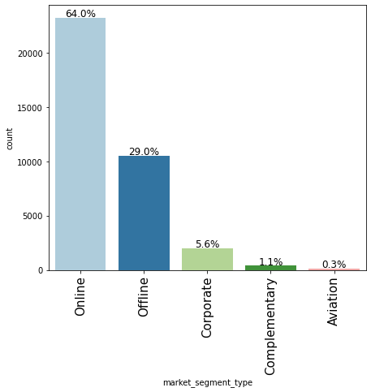

```python
labeled_barplot(df, "market_segment_type", perc=True)
```

**Repeated_guest:**

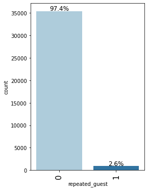

```python
labeled_barplot(df, "repeated_guest", perc=True)
```

- 97.4% of guests are not repeat guests, while 2.6% are.

**No_of_previous_cancellations:**

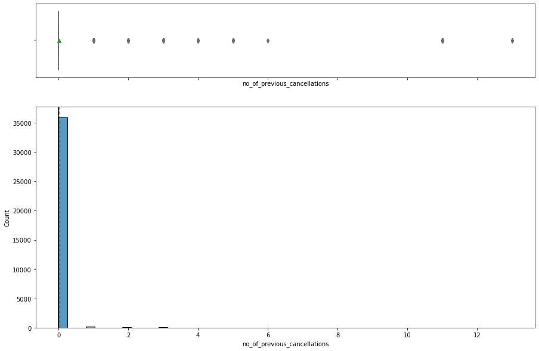

```python
histogram_boxplot(df, "no_of_previous_cancellations", bins=50)
```

- The vast majority of bookings have no previous cancellations.
- It appears that every data point above 0 is considered an outlier.

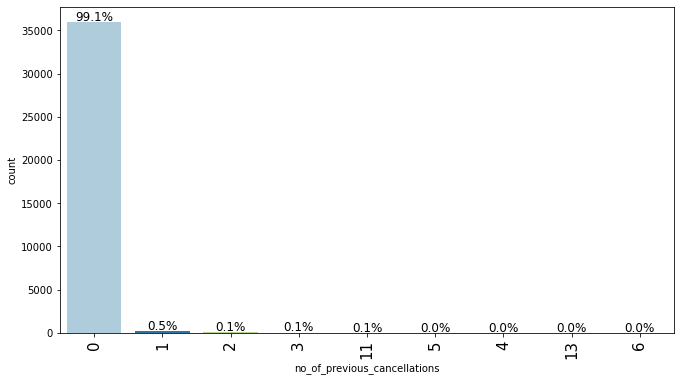

```python
labeled_barplot(df, "no_of_previous_cancellations", perc=True)
```

- Less than 1% of bookings have previous cancellations so this variable should probably be dropped.

**No_of_previous_bookings_not_canceled:**

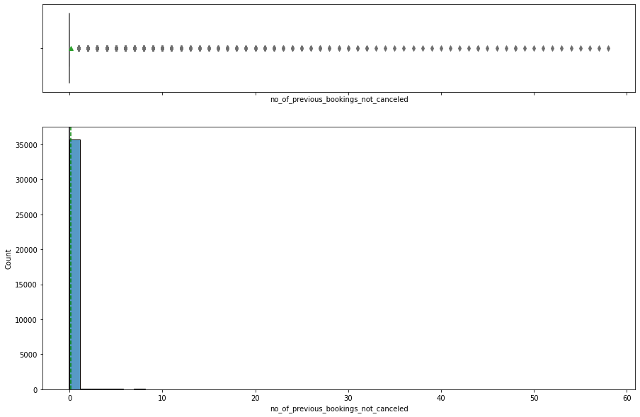

```python
histogram_boxplot(df, "no_of_previous_bookings_not_canceled", bins=50)
```

- The vast majority of bookings have no previous bookings.
- It appears that every data point above 0 is considered an outlier.
- This variable should be dropped.

**Avg_price_per_room:**

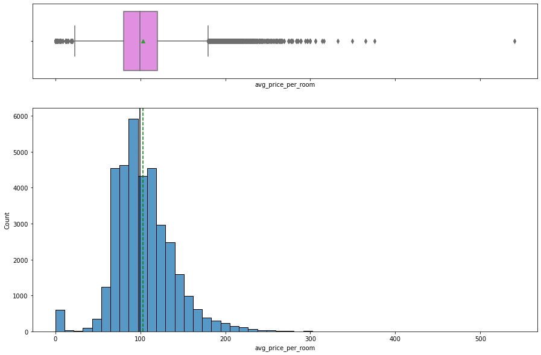

```python
histogram_boxplot(df, "avg_price_per_room", bins=50)
```

- The distribution appears close to normal.
- There are several outliers.
- Several rooms cost $0, which is not possible. This is likely because of missing data.

**No_of_special_requests:**

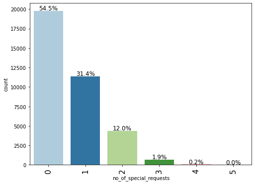

```python
labeled_barplot(df, "no_of_special_requests", perc=True)
```

- More than half of bookings don't contain any special requests.
- 31.4% of bookings include 1 and 12% contain 2.

**Booking_status:**

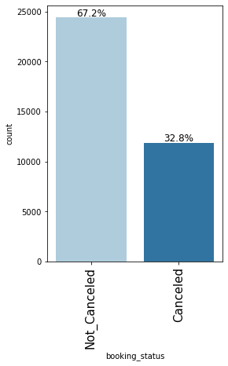

```python
labeled_barplot(df, "booking_status", perc=True)
```

- 67.2% of bookings are not canceled and 32.8% of bookings are canceled.

**Bivariate Analysis:**

**Correlation Check:**

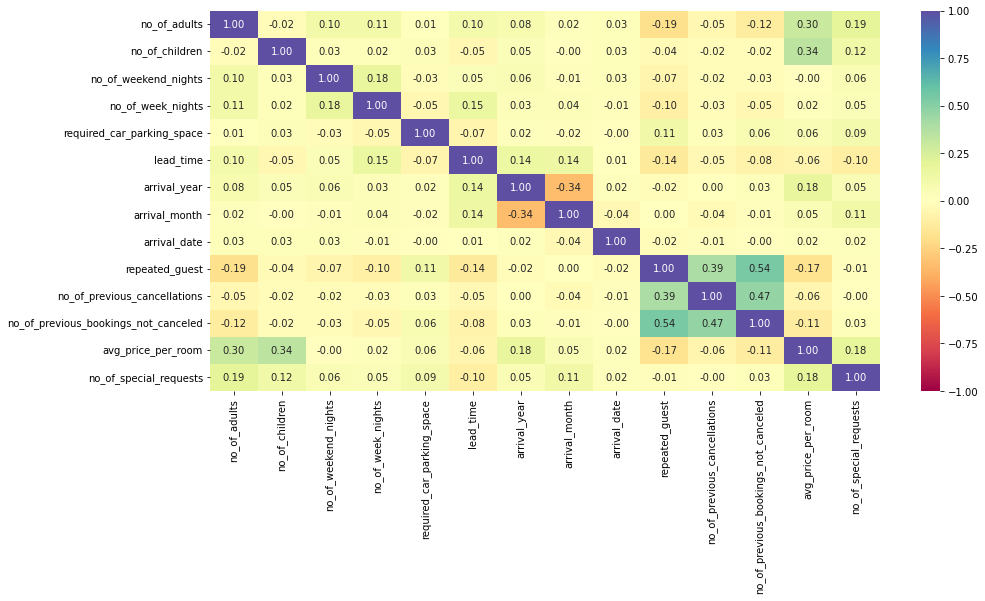

```python
plt.figure(figsize=(15, 7))
sns.heatmap(df.corr(), annot=True, vmin=-1, vmax=1, fmt=".2f", cmap="Spectral")
plt.show()
```

**Booking_status vs. no_of_previous_cancellations:**

```
no_of_previous_cancellations      0    1   2   3   4   5  6  11  13    All
booking_status
Not_Canceled                  24068  187  46  42  10  11  1  25   0  24390
All                           35937  198  46  43  10  11  1  25   4  36275
Canceled                      11869   11   0   1   0   0  0   0   4  11885
------------------------------------------------------------------------------------------------------------------------
```

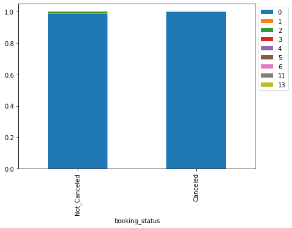

```python
stacked_barplot(df, "booking_status", "no_of_previous_cancellations")
```

- It appears that people with more previous cancellations aren't cancelling more than those without. In fact, they may be cancelling slightly less.

**Booking_status vs. repeated_guest:**

```
repeated_guest      0    1    All
booking_status
All             35345  930  36275
Not_Canceled    23476  914  24390
Canceled        11869   16  11885
------------------------------------------------------------------------------------------------------------------------
```

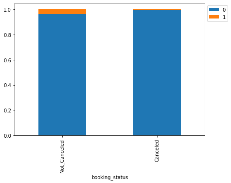

```python
stacked_barplot(df, "booking_status", "repeated_guest")
```

- Repeated guests seem less likely to cancel than non-repeats. This likely explains the high correlation between the two.

```
required_car_parking_space      0     1    All
booking_status
All                         35151  1124  36275
Not_Canceled                23380  1010  24390
Canceled                    11771   114  11885
------------------------------------------------------------------------------------------------------------------------
```

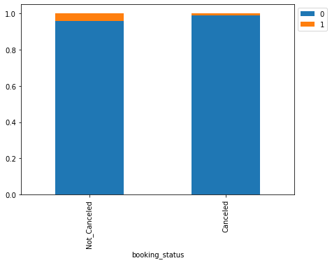

```python
stacked_barplot(df, "booking_status", "required_car_parking_space")
```

- A higher percentage of people that did not cancel their bookings also required car parking spaces.

**Booking_status vs. avg_price_per_room:**

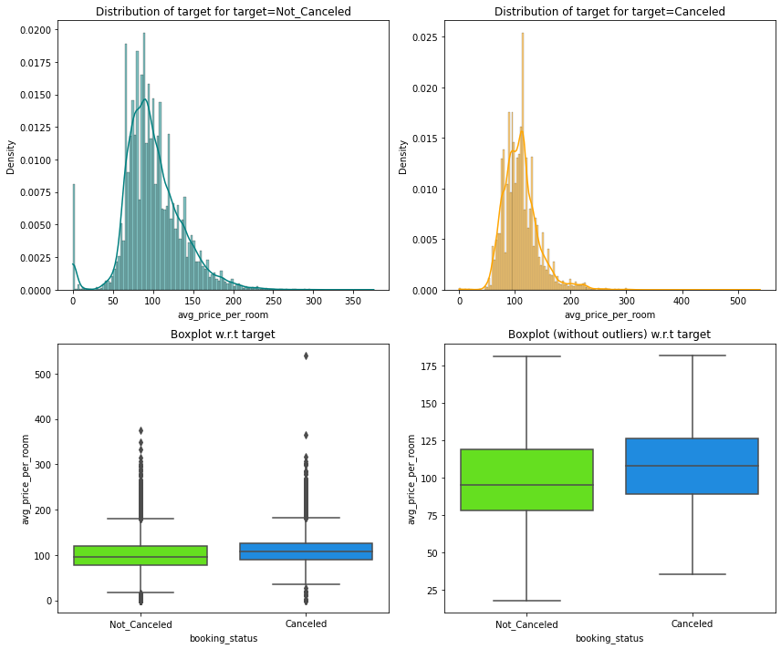

```python
distribution_plot_wrt_target(df, "avg_price_per_room", "booking_status")
```

- The average price per room is higher in canceled bookings.
- The average price per room in bookings that are not canceled is just below 100.

**Booking_status vs. no_of_weekend_nights:**

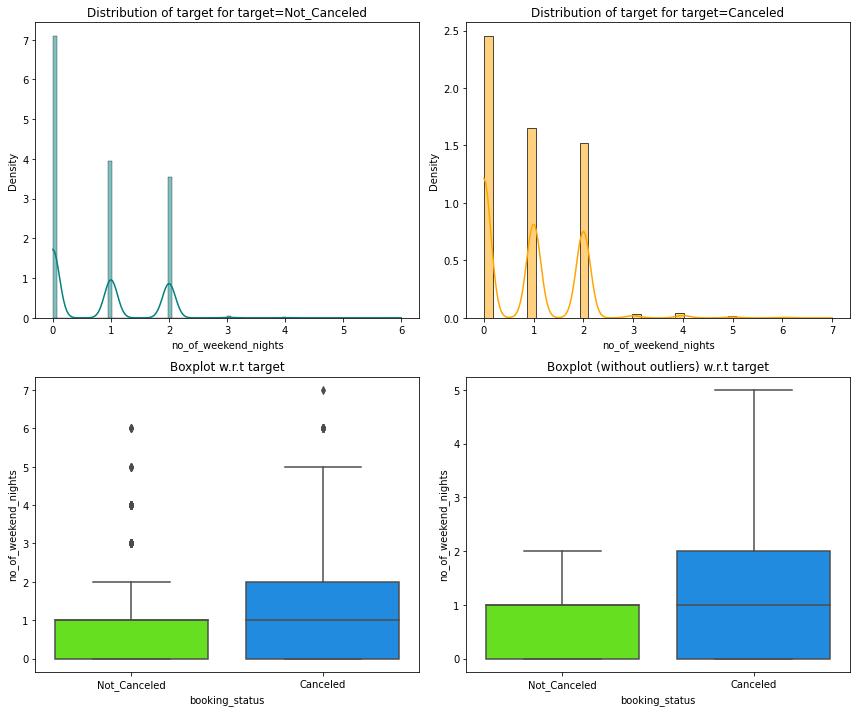

```python
distribution_plot_wrt_target(df, "no_of_weekend_nights", "booking_status")
```

- The average number of weekend nights is higher in bookings that were canceled.

**Booking_status vs. no_of_special_requests:**

```
no_of_special_requests      0      1     2    3   4  5    All
booking_status
Not_Canceled            11232   8670  3727  675  78  8  24390
All                     19777  11373  4364  675  78  8  36275
Canceled                 8545   2703   637    0   0  0  11885
------------------------------------------------------------------------------------------------------------------------
```

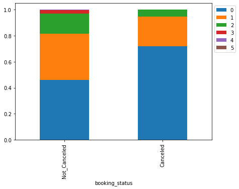

```python
stacked_barplot(df, "booking_status", "no_of_special_requests")
```

**Leading Questions**:

```python
df.loc[df["no_of_children"]==0].loc[df["no_of_adults"]==2]
```

|  | Booking_ID | no_of_adults | no_of_children | no_of_weekend_nights | no_of_week_nights | type_of_meal_plan | required_car_parking_space | room_type_reserved | lead_time | arrival_year | arrival_month | arrival_date | market_segment_type | repeated_guest | no_of_previous_cancellations | no_of_previous_bookings_not_canceled | avg_price_per_room | no_of_special_requests | booking_status |
| --- | --- | --- | --- | --- | --- | --- | --- | --- | --- | --- | --- | --- | --- | --- | --- | --- | --- | --- | --- |
| 0 | INN00001 | 2 | 0 | 1 | 2 | Meal Plan 1 | 0 | Room_Type 1 | 224 | 2017 | 10 | 2 | Offline | 0 | 0 | 0 | 65.00 | 0 | Not_Canceled |
| 1 | INN00002 | 2 | 0 | 2 | 3 | Not Selected | 0 | Room_Type 1 | 5 | 2018 | 11 | 6 | Online | 0 | 0 | 0 | 106.68 | 1 | Not_Canceled |
| 3 | INN00004 | 2 | 0 | 0 | 2 | Meal Plan 1 | 0 | Room_Type 1 | 211 | 2018 | 5 | 20 | Online | 0 | 0 | 0 | 100.00 | 0 | Canceled |
| 4 | INN00005 | 2 | 0 | 1 | 1 | Not Selected | 0 | Room_Type 1 | 48 | 2018 | 4 | 11 | Online | 0 | 0 | 0 | 94.50 | 0 | Canceled |
| 5 | INN00006 | 2 | 0 | 0 | 2 | Meal Plan 2 | 0 | Room_Type 1 | 346 | 2018 | 9 | 13 | Online | 0 | 0 | 0 | 115.00 | 1 | Canceled |
| ... | ... | ... | ... | ... | ... | ... | ... | ... | ... | ... | ... | ... | ... | ... | ... | ... | ... | ... | ... |
| 36267 | INN36268 | 2 | 0 | 1 | 0 | Not Selected | 0 | Room_Type 1 | 49 | 2018 | 7 | 11 | Online | 0 | 0 | 0 | 93.15 | 0 | Canceled |
| 36271 | INN36272 | 2 | 0 | 1 | 3 | Meal Plan 1 | 0 | Room_Type 1 | 228 | 2018 | 10 | 17 | Online | 0 | 0 | 0 | 90.95 | 2 | Canceled |
| 36272 | INN36273 | 2 | 0 | 2 | 6 | Meal Plan 1 | 0 | Room_Type 1 | 148 | 2018 | 7 | 1 | Online | 0 | 0 | 0 | 98.39 | 2 | Not_Canceled |
| 36273 | INN36274 | 2 | 0 | 0 | 3 | Not Selected | 0 | Room_Type 1 | 63 | 2018 | 4 | 21 | Online | 0 | 0 | 0 | 94.50 | 0 | Canceled |
| 36274 | INN36275 | 2 | 0 | 1 | 2 | Meal Plan 1 | 0 | Room_Type 1 | 207 | 2018 | 12 | 30 | Offline | 0 | 0 | 0 | 161.67 | 0 | Not_Canceled |

23719 rows × 19 columns

As seen above, couples without children make up 65% of bookings.

```python
df.groupby(["no_of_children"])["avg_price_per_room"].mean()
```

```
no_of_children
0     100.399182
1     122.325748
2     169.630652
3     154.594737
9      85.750000
10     84.450000
Name: avg_price_per_room, dtype: float64
```

## Data Preprocessing

- Missing value treatment (if needed)
- Feature engineering (if needed)
- Outlier detection and treatment (if needed)
- Preparing data for modeling
- Any other preprocessing steps (if needed)
- There are many outliers in the data. All the values smaller than the lower whisker will be assigned the value of the lower whisker, and all the values above the upper whisker will be assigned the value of the upper whisker.
- We will drop repeated_guest, no_of_previous_bookings_not_canceled, no_of_previous_cancellations, and required_parking_space because 90+% of these observations are 0.

**Dropping repeated_guest, no_of_previous_bookings_not_canceled, no_of_previous_cancellations, and required_parking_space:**

```python
data.drop(["repeated_guest", "no_of_previous_bookings_not_canceled", "no_of_previous_cancellations", "required_car_parking_space", "no_of_children", "room_type_reserved"], axis=1, inplace=True)
```

**Missing Value Treatment:**

```python
data["no_of_adults"] = data["no_of_adults"].replace(0,data["no_of_adults"].mean())
data["avg_price_per_room"] = data["avg_price_per_room"].replace(0,data["avg_price_per_room"].mean())
```

```python
data.describe().T
```

|  | count | mean | std | min | 25% | 50% | 75% | max |
| --- | --- | --- | --- | --- | --- | --- | --- | --- |
| no_of_adults | 36275.0 | 1.852032 | 0.505936 | 1.0 | 2.0 | 2.0 | 2.0 | 4.0 |
| no_of_weekend_nights | 36275.0 | 0.810724 | 0.870644 | 0.0 | 0.0 | 1.0 | 2.0 | 7.0 |
| no_of_week_nights | 36275.0 | 2.204300 | 1.410905 | 0.0 | 1.0 | 2.0 | 3.0 | 17.0 |
| lead_time | 36275.0 | 85.232557 | 85.930817 | 0.0 | 17.0 | 57.0 | 126.0 | 443.0 |
| arrival_year | 36275.0 | 2017.820427 | 0.383836 | 2017.0 | 2018.0 | 2018.0 | 2018.0 | 2018.0 |
| arrival_month | 36275.0 | 7.423653 | 3.069894 | 1.0 | 5.0 | 8.0 | 10.0 | 12.0 |
| arrival_date | 36275.0 | 15.596995 | 8.740447 | 1.0 | 8.0 | 16.0 | 23.0 | 31.0 |
| avg_price_per_room | 36275.0 | 104.977387 | 32.682477 | 0.5 | 81.0 | 100.0 | 120.0 | 540.0 |
| no_of_special_requests | 36275.0 | 0.619655 | 0.786236 | 0.0 | 0.0 | 0.0 | 1.0 | 5.0 |

**Outlier Detection:**

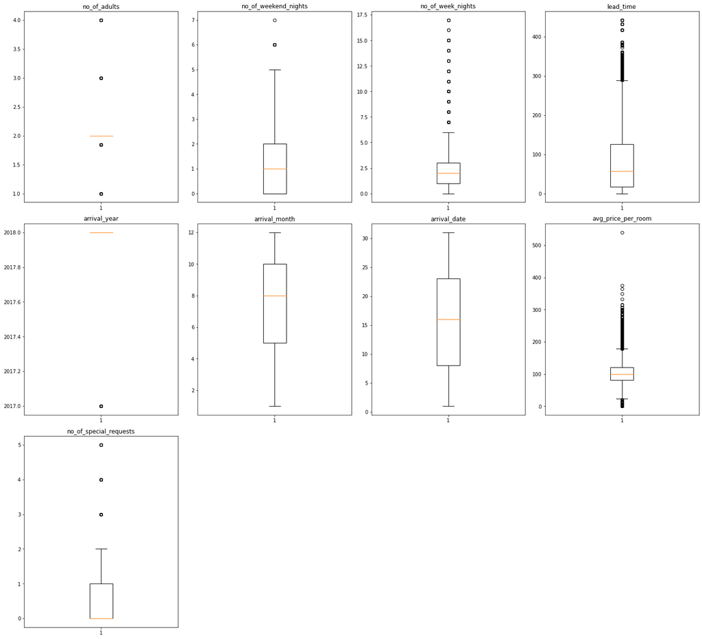

```python
numerical_col = data.select_dtypes(include=np.number).columns.tolist()
plt.figure(figsize=(20, 30))

for i, variable in enumerate(numerical_col):
    plt.subplot(5, 4, i + 1)
    plt.boxplot(data[variable], whis=1.5)
    plt.tight_layout()
    plt.title(variable)

plt.show()
```

**Outlier Treatment:**

```python
# functions to treat outliers by flooring and capping


def treat_outliers(df, col):
    """
    Treats outliers in a variable

    df: dataframe
    col: dataframe column
    """
    Q1 = df[col].quantile(0.25)  # 25th quantile
    Q3 = df[col].quantile(0.75)  # 75th quantile
    IQR = Q3 - Q1
    Lower_Whisker = Q1 - 1.5 * IQR
    Upper_Whisker = Q3 + 1.5 * IQR

    # all the values smaller than Lower_Whisker will be assigned the value of Lower_Whisker
    # all the values greater than Upper_Whisker will be assigned the value of Upper_Whisker
    df[col] = np.clip(df[col], Lower_Whisker, Upper_Whisker)

    return df


def treat_outliers_all(df, col_list):
    """
    Treat outliers in a list of variables

    df: dataframe
    col_list: list of dataframe columns
    """
    for c in col_list:
        df = treat_outliers(df, c)
    return df
```

```python
numerical_col = data.select_dtypes(include='number').columns.tolist()
data = treat_outliers_all(data, numerical_col)
```

## EDA

- It is a good idea to explore the data once again after manipulating it.

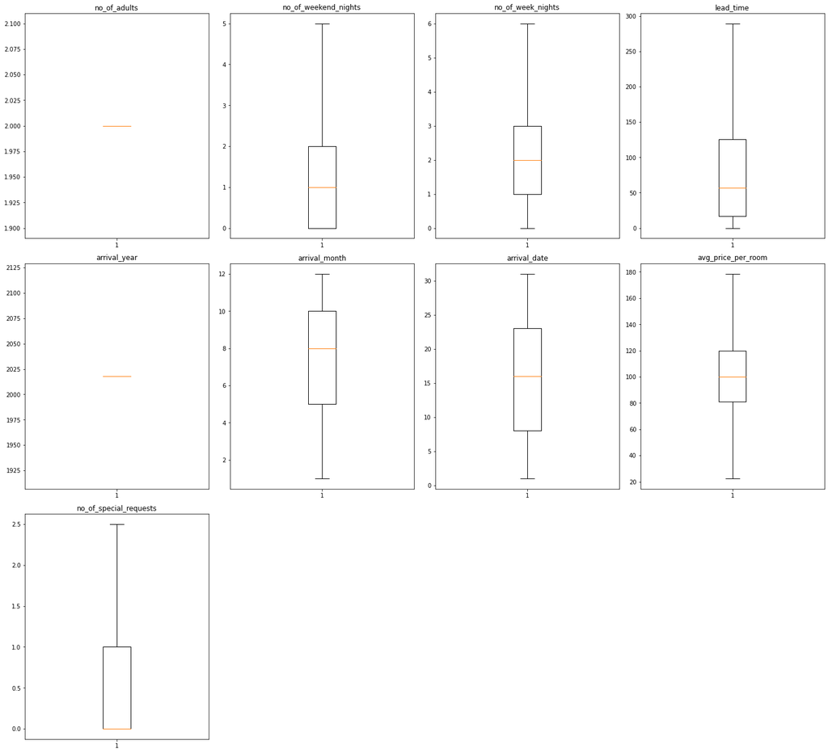

```python
# let's look at box plot to see if outliers have been treated or not
plt.figure(figsize=(20, 30))

for i, variable in enumerate(numerical_col):
    plt.subplot(5, 4, i + 1)
    plt.boxplot(data[variable], whis=1.5)
    plt.tight_layout()
    plt.title(variable)

plt.show()
```

No more outliers are present, as intended.

```python
# Next, convert booking status to booleans.
data["booking_status"] = data["booking_status"].apply(lambda x: 1 if x == "Not_Canceled" else 0)
```

```python
data.head()
```

|  | Booking_ID | no_of_adults | no_of_weekend_nights | no_of_week_nights | type_of_meal_plan | lead_time | arrival_year | arrival_month | arrival_date | market_segment_type | avg_price_per_room | no_of_special_requests | booking_status |
| --- | --- | --- | --- | --- | --- | --- | --- | --- | --- | --- | --- | --- | --- |
| 0 | INN00001 | 2.0 | 1.0 | 2.0 | Meal Plan 1 | 224.0 | 2018.0 | 10 | 2 | Offline | 65.00 | 0.0 | 1 |
| 1 | INN00002 | 2.0 | 2.0 | 3.0 | Not Selected | 5.0 | 2018.0 | 11 | 6 | Online | 106.68 | 1.0 | 1 |
| 2 | INN00003 | 2.0 | 2.0 | 1.0 | Meal Plan 1 | 1.0 | 2018.0 | 2 | 28 | Online | 60.00 | 0.0 | 0 |
| 3 | INN00004 | 2.0 | 0.0 | 2.0 | Meal Plan 1 | 211.0 | 2018.0 | 5 | 20 | Online | 100.00 | 0.0 | 0 |
| 4 | INN00005 | 2.0 | 1.0 | 1.0 | Not Selected | 48.0 | 2018.0 | 4 | 11 | Online | 94.50 | 0.0 | 0 |

```python
data2 = data.copy()
```

The lambda function worked as intended.

```python
# create dummy variables for type_of_meal_plan and room_type_reserved
data = pd.get_dummies(data, columns = ["market_segment_type", "type_of_meal_plan"], drop_first = True)
data.head()
```

|  | Booking_ID | no_of_adults | no_of_weekend_nights | no_of_week_nights | lead_time | arrival_year | arrival_month | arrival_date | avg_price_per_room | no_of_special_requests | booking_status | market_segment_type_Complementary | market_segment_type_Corporate | market_segment_type_Offline | market_segment_type_Online | type_of_meal_plan_Meal Plan 2 | type_of_meal_plan_Meal Plan 3 | type_of_meal_plan_Not Selected |
| --- | --- | --- | --- | --- | --- | --- | --- | --- | --- | --- | --- | --- | --- | --- | --- | --- | --- | --- |
| 0 | INN00001 | 2.0 | 1.0 | 2.0 | 224.0 | 2018.0 | 10 | 2 | 65.00 | 0.0 | 1 | 0 | 0 | 1 | 0 | 0 | 0 | 0 |
| 1 | INN00002 | 2.0 | 2.0 | 3.0 | 5.0 | 2018.0 | 11 | 6 | 106.68 | 1.0 | 1 | 0 | 0 | 0 | 1 | 0 | 0 | 1 |
| 2 | INN00003 | 2.0 | 2.0 | 1.0 | 1.0 | 2018.0 | 2 | 28 | 60.00 | 0.0 | 0 | 0 | 0 | 0 | 1 | 0 | 0 | 0 |
| 3 | INN00004 | 2.0 | 0.0 | 2.0 | 211.0 | 2018.0 | 5 | 20 | 100.00 | 0.0 | 0 | 0 | 0 | 0 | 1 | 0 | 0 | 0 |
| 4 | INN00005 | 2.0 | 1.0 | 1.0 | 48.0 | 2018.0 | 4 | 11 | 94.50 | 0.0 | 0 | 0 | 0 | 0 | 1 | 0 | 0 | 1 |

```python
# remove type_of_meal_plan_3 and market_segment_type_Complementary because that columns has too few non-zero values
data.drop(["type_of_meal_plan_Meal Plan 3", "market_segment_type_Complementary"], axis=1, inplace=True)
data.head()
```

|  | Booking_ID | no_of_adults | no_of_weekend_nights | no_of_week_nights | lead_time | arrival_year | arrival_month | arrival_date | avg_price_per_room | no_of_special_requests | booking_status | market_segment_type_Corporate | market_segment_type_Offline | market_segment_type_Online | type_of_meal_plan_Meal Plan 2 | type_of_meal_plan_Not Selected |
| --- | --- | --- | --- | --- | --- | --- | --- | --- | --- | --- | --- | --- | --- | --- | --- | --- |
| 0 | INN00001 | 2.0 | 1.0 | 2.0 | 224.0 | 2018.0 | 10 | 2 | 65.00 | 0.0 | 1 | 0 | 1 | 0 | 0 | 0 |
| 1 | INN00002 | 2.0 | 2.0 | 3.0 | 5.0 | 2018.0 | 11 | 6 | 106.68 | 1.0 | 1 | 0 | 0 | 1 | 0 | 1 |
| 2 | INN00003 | 2.0 | 2.0 | 1.0 | 1.0 | 2018.0 | 2 | 28 | 60.00 | 0.0 | 0 | 0 | 0 | 1 | 0 | 0 |
| 3 | INN00004 | 2.0 | 0.0 | 2.0 | 211.0 | 2018.0 | 5 | 20 | 100.00 | 0.0 | 0 | 0 | 0 | 1 | 0 | 0 |
| 4 | INN00005 | 2.0 | 1.0 | 1.0 | 48.0 | 2018.0 | 4 | 11 | 94.50 | 0.0 | 0 | 0 | 0 | 1 | 0 | 1 |

Lastly, drop Booking_ID as those codes are randomly generated and shouldn't give any information about whether someone will cancel a booking.

```python
data.drop(["Booking_ID"], axis=1, inplace=True)
data.head()
```

|  | no_of_adults | no_of_weekend_nights | no_of_week_nights | lead_time | arrival_year | arrival_month | arrival_date | avg_price_per_room | no_of_special_requests | booking_status | market_segment_type_Corporate | market_segment_type_Offline | market_segment_type_Online | type_of_meal_plan_Meal Plan 2 | type_of_meal_plan_Not Selected |
| --- | --- | --- | --- | --- | --- | --- | --- | --- | --- | --- | --- | --- | --- | --- | --- |
| 0 | 2.0 | 1.0 | 2.0 | 224.0 | 2018.0 | 10 | 2 | 65.00 | 0.0 | 1 | 0 | 1 | 0 | 0 | 0 |
| 1 | 2.0 | 2.0 | 3.0 | 5.0 | 2018.0 | 11 | 6 | 106.68 | 1.0 | 1 | 0 | 0 | 1 | 0 | 1 |
| 2 | 2.0 | 2.0 | 1.0 | 1.0 | 2018.0 | 2 | 28 | 60.00 | 0.0 | 0 | 0 | 0 | 1 | 0 | 0 |
| 3 | 2.0 | 0.0 | 2.0 | 211.0 | 2018.0 | 5 | 20 | 100.00 | 0.0 | 0 | 0 | 0 | 1 | 0 | 0 |
| 4 | 2.0 | 1.0 | 1.0 | 48.0 | 2018.0 | 4 | 11 | 94.50 | 0.0 | 0 | 0 | 0 | 1 | 0 | 1 |

**Create training and test sets**

```python
# specifying the independent  and dependent variables
X = data.drop(["booking_status"], axis=1)
Y = data["booking_status"]

# adding a constant to the independent variables
X = sm.add_constant(X)

# splitting data in train and test sets
X_train, X_test, y_train, y_test = train_test_split(
    X, Y, test_size=0.30, random_state=1
)
```

```python
print("Shape of Training set : ", X_train.shape)
print("Shape of test set : ", X_test.shape)
print("Percentage of classes in training set:")
print(y_train.value_counts(normalize=True))
print("Percentage of classes in test set:")
print(y_test.value_counts(normalize=True))
```

```
Shape of Training set :  (25392, 14)
Shape of test set :  (10883, 14)
Percentage of classes in training set:
1    0.670644
0    0.329356
Name: booking_status, dtype: float64
Percentage of classes in test set:
1    0.676376
0    0.323624
Name: booking_status, dtype: float64
```

## Checking Multicollinearity

- In order to make statistical inferences from a logistic regression model, it is important to ensure that there is no multicollinearity present in the data.

```python
vif_series = pd.Series(
    [variance_inflation_factor(X_train.values, i) for i in range(X_train.shape[1])],
    index=X_train.columns,
    dtype=float,
)
print("Series before feature selection: \n\n{}\n".format(vif_series))
```

```
Series before feature selection:

no_of_adults                       0.000000
no_of_weekend_nights               1.044498
no_of_week_nights                  1.077724
lead_time                          1.227977
arrival_year                       0.000000
arrival_month                      1.049804
arrival_date                       1.004808
avg_price_per_room                 1.318876
no_of_special_requests             1.216400
market_segment_type_Corporate      4.674094
market_segment_type_Offline       15.835763
market_segment_type_Online        17.187306
type_of_meal_plan_Meal Plan 2      1.190669
type_of_meal_plan_Not Selected     1.180223
dtype: float64
```

```python
# It is likely there is a collinearity relationship between market_segment_type_Offline and market_segment_type_Online, so remove market_type_Online
X_train = X_train.drop(["market_segment_type_Online"], axis=1)
```

```python
vif_series = pd.Series(
    [variance_inflation_factor(X_train.values, i) for i in range(X_train.shape[1])],
    index=X_train.columns,
    dtype=float,
)
print("Series before feature selection: \n\n{}\n".format(vif_series))
```

```
Series before feature selection:

no_of_adults                      0.000000
no_of_weekend_nights              1.041649
no_of_week_nights                 1.074268
lead_time                         1.213696
arrival_year                      0.000000
arrival_month                     1.048482
arrival_date                      1.004775
avg_price_per_room                1.306682
no_of_special_requests            1.214788
market_segment_type_Corporate     1.230585
market_segment_type_Offline       1.586450
type_of_meal_plan_Meal Plan 2     1.190410
type_of_meal_plan_Not Selected    1.166138
dtype: float64
```

No more multicollinearity present.

## Building a Logistic Regression model

```python
# fitting logistic regression model
logit = sm.Logit(y_train, X_train.astype(float))
lg = logit.fit(disp=False)

print(lg.summary())
```

```
                           Logit Regression Results
==============================================================================
Dep. Variable:         booking_status   No. Observations:                25392
Model:                          Logit   Df Residuals:                    25379
Method:                           MLE   Df Model:                           12
Date:                Fri, 17 Feb 2023   Pseudo R-squ.:                  0.3117
Time:                        14:50:37   Log-Likelihood:                -11076.
converged:                       True   LL-Null:                       -16091.
Covariance Type:            nonrobust   LLR p-value:                     0.000
==================================================================================================
                                     coef    std err          z      P>|z|      [0.025      0.975]
--------------------------------------------------------------------------------------------------
no_of_adults                    4.353e-06   3.41e+05   1.28e-11      1.000   -6.69e+05    6.69e+05
no_of_weekend_nights              -0.1215      0.019     -6.270      0.000      -0.159      -0.083
no_of_week_nights                 -0.0235      0.013     -1.764      0.078      -0.050       0.003
lead_time                         -0.0170      0.000    -65.492      0.000      -0.018      -0.017
arrival_year                       0.0014    338.291   4.21e-06      1.000    -663.036     663.039
arrival_month                      0.0610      0.006     10.340      0.000       0.049       0.073
arrival_date                      -0.0011      0.002     -0.552      0.581      -0.005       0.003
avg_price_per_room                -0.0194      0.001    -29.608      0.000      -0.021      -0.018
no_of_special_requests             1.4610      0.029     49.676      0.000       1.403       1.519
market_segment_type_Corporate      0.9618      0.098      9.788      0.000       0.769       1.154
market_segment_type_Offline        1.7200      0.051     34.010      0.000       1.621       1.819
type_of_meal_plan_Meal Plan 2     -0.1509      0.062     -2.444      0.015      -0.272      -0.030
type_of_meal_plan_Not Selected    -0.4651      0.051     -9.185      0.000      -0.564      -0.366
==================================================================================================
```

```python
# remove p values above .05 iteratively:
# initial list of columns
cols = X_train.columns.tolist()

# setting an initial max p-value
max_p_value = 1

while len(cols) > 0:
    # defining the train set
    X_train_aux = X_train[cols]

    # fitting the model
    model = sm.Logit(y_train, X_train_aux).fit(disp=False)

    # getting the p-values and the maximum p-value
    p_values = model.pvalues
    max_p_value = max(p_values)

    # name of the variable with maximum p-value
    feature_with_p_max = p_values.idxmax()

    if max_p_value > 0.05:
        cols.remove(feature_with_p_max)
    else:
        break

selected_features = cols
print(selected_features)
```

```
['no_of_weekend_nights', 'lead_time', 'arrival_year', 'arrival_month', 'avg_price_per_room', 'no_of_special_requests', 'market_segment_type_Corporate', 'market_segment_type_Offline', 'type_of_meal_plan_Meal Plan 2', 'type_of_meal_plan_Not Selected']
```

```python
X_train2 = X_train[selected_features]
```

```python
logit3 = sm.Logit(y_train, X_train2.astype(float))
lg3 = logit3.fit(disp=False)

print(lg3.summary())
```

```
                           Logit Regression Results
==============================================================================
Dep. Variable:         booking_status   No. Observations:                25392
Model:                          Logit   Df Residuals:                    25382
Method:                           MLE   Df Model:                            9
Date:                Fri, 17 Feb 2023   Pseudo R-squ.:                  0.3116
Time:                        14:50:37   Log-Likelihood:                -11078.
converged:                       True   LL-Null:                       -16091.
Covariance Type:            nonrobust   LLR p-value:                     0.000
==================================================================================================
                                     coef    std err          z      P>|z|      [0.025      0.975]
--------------------------------------------------------------------------------------------------
no_of_weekend_nights              -0.1257      0.019     -6.531      0.000      -0.163      -0.088
lead_time                         -0.0171      0.000    -66.340      0.000      -0.018      -0.017
arrival_year                       0.0014   4.47e-05     31.105      0.000       0.001       0.001
arrival_month                      0.0612      0.006     10.387      0.000       0.050       0.073
avg_price_per_room                -0.0194      0.001    -29.578      0.000      -0.021      -0.018
no_of_special_requests             1.4592      0.029     49.673      0.000       1.402       1.517
market_segment_type_Corporate      0.9729      0.098      9.940      0.000       0.781       1.165
market_segment_type_Offline        1.7277      0.050     34.254      0.000       1.629       1.827
type_of_meal_plan_Meal Plan 2     -0.1447      0.062     -2.347      0.019      -0.265      -0.024
type_of_meal_plan_Not Selected    -0.4560      0.050     -9.061      0.000      -0.555      -0.357
==================================================================================================
```

**Observations:**

- We will use this as our final model since all p values are < .05
- Positive values of market_segment_type_Offline and and no_of_special_requests indicate a higher probaility, among others, of someone not canceling.
- Negative values of no_of_weekend_nights and meal plan not_selected indicate a higher probability of someone canceling.

```python
# defining a function to compute different metrics to check performance of a classification model built using statsmodels
def model_performance_classification_statsmodels(
    model, predictors, target, threshold=0.5
):
    """
    Function to compute different metrics to check classification model performance

    model: classifier
    predictors: independent variables
    target: dependent variable
    threshold: threshold for classifying the observation as class 1
    """

    # checking which probabilities are greater than threshold
    pred_temp = model.predict(predictors) > threshold
    # rounding off the above values to get classes
    pred = np.round(pred_temp)

    acc = accuracy_score(target, pred)  # to compute Accuracy
    recall = recall_score(target, pred)  # to compute Recall
    precision = precision_score(target, pred)  # to compute Precision
    f1 = f1_score(target, pred)  # to compute F1-score

    # creating a dataframe of metrics
    df_perf = pd.DataFrame(
        {"Accuracy": acc, "Recall": recall, "Precision": precision, "F1": f1,},
        index=[0],
    )

    return df_perf
```

```python
# defining a function to plot the confusion_matrix of a classification model


def confusion_matrix_statsmodels(model, predictors, target, threshold=0.5):
    """
    To plot the confusion_matrix with percentages

    model: classifier
    predictors: independent variables
    target: dependent variable
    threshold: threshold for classifying the observation as class 1
    """
    y_pred = model.predict(predictors) > threshold
    cm = confusion_matrix(target, y_pred)
    labels = np.asarray(
        [
            ["{0:0.0f}".format(item) + "\n{0:.2%}".format(item / cm.flatten().sum())]
            for item in cm.flatten()
        ]
    ).reshape(2, 2)

    plt.figure(figsize=(6, 4))
    sns.heatmap(cm, annot=labels, fmt="")
    plt.ylabel("True label")
    plt.xlabel("Predicted label")
```

```python
print("Training performance:")
model_performance_classification_statsmodels(lg, X_train, y_train)
```

```
Training performance:
```

|  | Accuracy | Recall | Precision | F1 |
| --- | --- | --- | --- | --- |
| 0 | 0.798559 | 0.889541 | 0.824067 | 0.855553 |

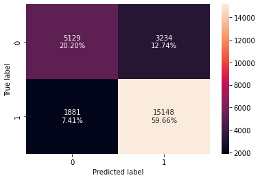

```python
confusion_matrix_statsmodels(lg, X_train, y_train)
```

- On the training data, precision, recall, and the F1 scores are all above 80%. Accuracy is almost 80%. These scores are indicative of a good model.
- False positives are more prominent than false negatives. This may suit the needs of the customer because missing a canceled booking is likely expensive.

```python
log_reg_model_train_perf = model_performance_classification_statsmodels(
    lg3, X_train2, y_train
)

print("Training performance:")
log_reg_model_train_perf
```

```
Training performance:
```

|  | Accuracy | Recall | Precision | F1 |
| --- | --- | --- | --- | --- |
| 0 | 0.798677 | 0.88913 | 0.824449 | 0.855569 |

**Test set performance**

- We have to first drop the columns from the test set that were dropped from the training set.

```python
X_test2 = X_test[list(X_train2.columns)]
```

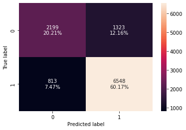

```python
# creating confusion matrix
confusion_matrix_statsmodels(lg3, X_test2, y_test)
```

```python
log_reg_model_test_perf = model_performance_classification_statsmodels(
    lg3, X_test2, y_test
)

print("Test performance:")
log_reg_model_test_perf
```

```
Test performance:
```

|  | Accuracy | Recall | Precision | F1 |
| --- | --- | --- | --- | --- |
| 0 | 0.803731 | 0.889553 | 0.831915 | 0.859769 |

- The model is giving a good f1_score of ~0.85 on both the train and test sets.
- As the train and test performances are comparable, the model is not overfitting.

**Model performance improvement:**

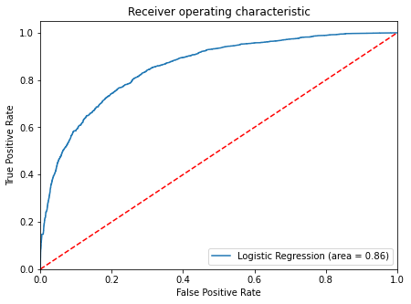

```python
# check the ROC curve:
logit_roc_auc_train = roc_auc_score(y_train, lg3.predict(X_train2))
fpr, tpr, thresholds = roc_curve(y_train, lg3.predict(X_train2))
plt.figure(figsize=(7, 5))
plt.plot(fpr, tpr, label="Logistic Regression (area = %0.2f)" % logit_roc_auc_train)
plt.plot([0, 1], [0, 1], "r--")
plt.xlim([0.0, 1.0])
plt.ylim([0.0, 1.05])
plt.xlabel("False Positive Rate")
plt.ylabel("True Positive Rate")
plt.title("Receiver operating characteristic")
plt.legend(loc="lower right")
plt.show()
```

- Logistic Regression model is giving a good performance on training set.

```python
# Optimal threshold as per AUC-ROC curve
# The optimal cut off would be where tpr is high and fpr is low
fpr, tpr, thresholds = roc_curve(y_train, lg3.predict(X_train2))

optimal_idx = np.argmax(tpr - fpr)
optimal_threshold_auc_roc = thresholds[optimal_idx]
print(optimal_threshold_auc_roc)
```

```
0.6908187833796947
```

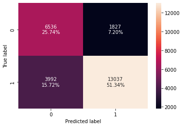

```python
# creating confusion matrix
confusion_matrix_statsmodels(
    lg3, X_train2, y_train, threshold=optimal_threshold_auc_roc
)
```

```python
# checking model performance for this model
log_reg_model_train_perf_threshold_auc_roc = model_performance_classification_statsmodels(
    lg3, X_train2, y_train, threshold=optimal_threshold_auc_roc
)
print("Training performance:")
log_reg_model_train_perf_threshold_auc_roc
```

```
Training performance:
```

|  | Accuracy | Recall | Precision | F1 |
| --- | --- | --- | --- | --- |
| 0 | 0.770833 | 0.765576 | 0.877086 | 0.817546 |

- Precision has increased but all other metrics have decreased.
- The model is still giving good performance.

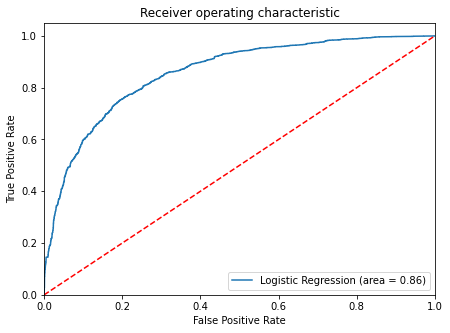

```python
# checking model performance on test set
logit_roc_auc_train = roc_auc_score(y_test, lg3.predict(X_test2))
fpr, tpr, thresholds = roc_curve(y_test, lg3.predict(X_test2))
plt.figure(figsize=(7, 5))
plt.plot(fpr, tpr, label="Logistic Regression (area = %0.2f)" % logit_roc_auc_train)
plt.plot([0, 1], [0, 1], "r--")
plt.xlim([0.0, 1.0])
plt.ylim([0.0, 1.05])
plt.xlabel("False Positive Rate")
plt.ylabel("True Positive Rate")
plt.title("Receiver operating characteristic")
plt.legend(loc="lower right")
plt.show()
```

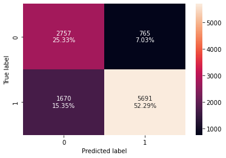

```python
# creating confusion matrix
confusion_matrix_statsmodels(lg3, X_test2, y_test, threshold=optimal_threshold_auc_roc)
```

- The logistic regression model is giving good performance on the test set.

```python
# checking model performance for this model
log_reg_model_test_perf_threshold_auc_roc = model_performance_classification_statsmodels(
    lg3, X_test2, y_test, threshold=optimal_threshold_auc_roc
)
print("Test performance:")
log_reg_model_test_perf_threshold_auc_roc
```

```
Test performance:
```

|  | Accuracy | Recall | Precision | F1 |
| --- | --- | --- | --- | --- |
| 0 | 0.776257 | 0.773129 | 0.881506 | 0.823768 |

Precision/Recall curve:

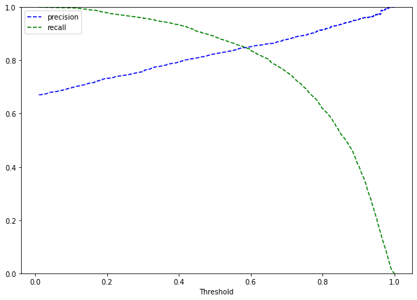

```python
y_scores = lg3.predict(X_train2)
prec, rec, tre = precision_recall_curve(y_train, y_scores,)


def plot_prec_recall_vs_tresh(precisions, recalls, thresholds):
    plt.plot(thresholds, precisions[:-1], "b--", label="precision")
    plt.plot(thresholds, recalls[:-1], "g--", label="recall")
    plt.xlabel("Threshold")
    plt.legend(loc="upper left")
    plt.ylim([0, 1])


plt.figure(figsize=(10, 7))
plot_prec_recall_vs_tresh(prec, rec, tre)
plt.show()
```

- At the threshold of .6, we get optimal precision and recall.

```python
# setting the threshold
optimal_threshold_curve = 0.6
```